# Assignment 4: Incarceration

Edward Wu

2022-11-22

## Abstract

For this report, the main points are the trend of incarceration and county-level variability makes different and theoretically-grounded studies of the high rates of incarceration seen across the United States. These purposes are vital because incarceration is the most intuitive example of studying crime rate and crime ratio. To explore this aspect, I will analyze dataset from incarceration-trends and provide several plots for data visualization.

## Introduction

Incarceration is the act of imprisoning someone or the state of being imprisoned. It can reflect changes in the level of law and order in various places, the type of criminal detention, and the crime rate. However, this set of data also expose patterns of inequality by listing incarceration rates by gender, race and region. Different descriptions will cause different results and value orientation. Therefore, it may lead to framing effects which focus on subjective bias that leads people to make evaluations based on benefits and harms. When people see that Latinos and African Americans make up a large percentage of the criminal population, they would develop a race-based bias which would cause racial criminalization and racial disparities. According to the data of Vera institute, black people are twice as likely to be arrested as white people. Therefore, drastically reducing the use of jails, prisons, and detention centers is necessary.

For the direct stakeholders, they are the users and researchers who take the dataset. They can draw conclusions and publish persuasive reports through data analysis. For the indirect stakeholders, they are the jails whose structures have been improved by data analysis. Also they are rationally deployed judges and judicial system.

Questions: Which state has the most prisoners? What is the changing trend of criminals in the past three years? What is the mean of total criminals in the past three years?

## Secion 3

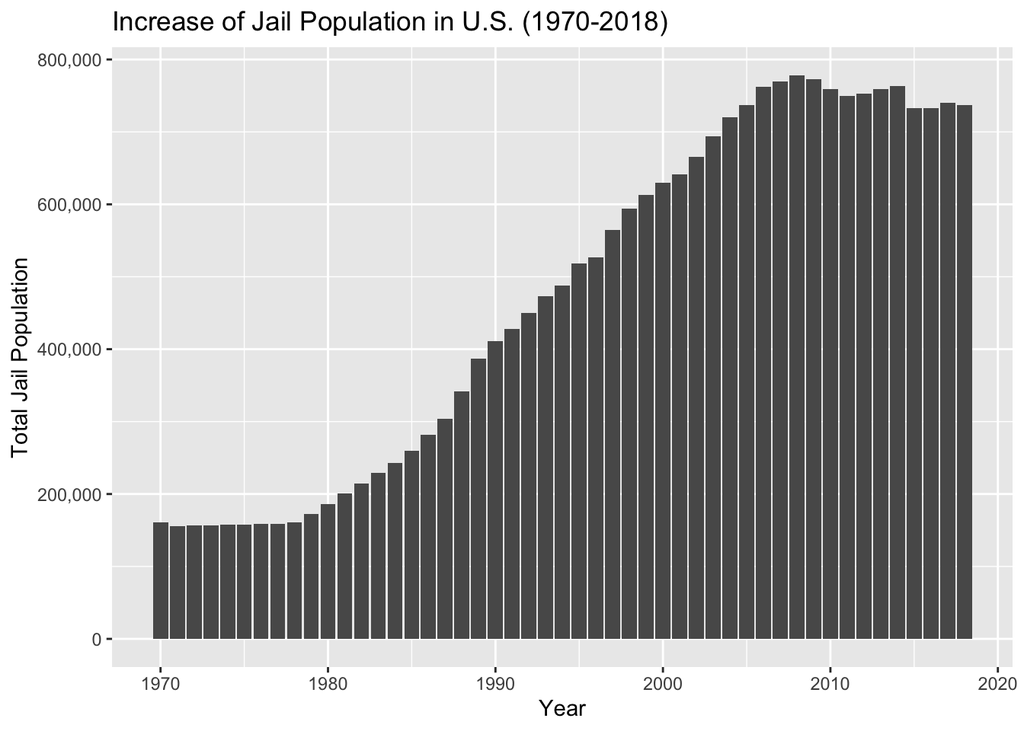

```r
plot_jail_pop_for_us()
```

Unfortunately, while society has been evolving, the number of people going to prison has been on the rise. This is a threat to the security of the country and the daily life of the people. What’s more, this upward trend didn’t stop and slowed down until around 2010, which is good news.

## Secion 4

[figure not shown]

```r
plot_jail_pop_for_states(select_state)
```

According to the three lines from the chart, after comparing the trends in these three states, I found that California has the fastest and largest population growth rate. Comparing Washington state and Wyoming, their curve is relatively flat. But the Washington state with large population and the economic growth is faster. These lines reflect regional difference.

## Secion 5

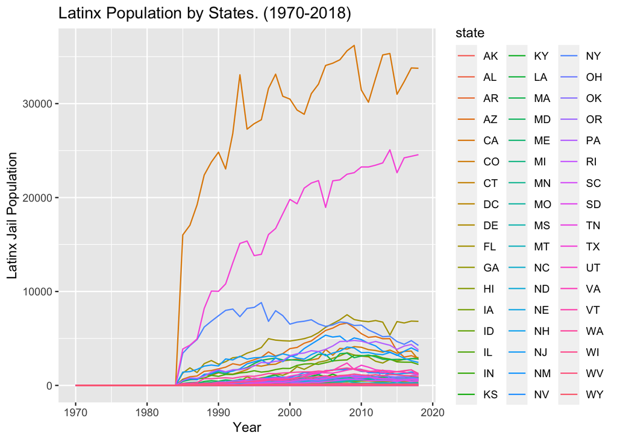

```r
plot_latinx_pop_by_states()
```

## Section 6

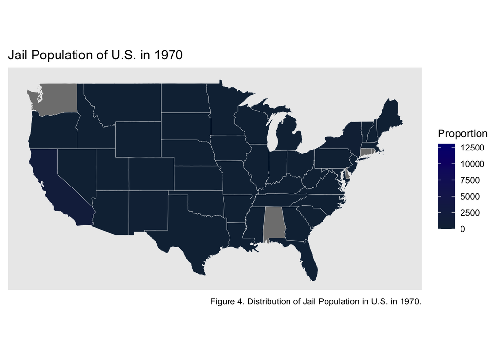

```r
plot_jail_pop_1970()
```

[figure not shown]

```r
plot_jail_pop_2016()
```

By comparing the prison population distribution of the two maps, the number and density of prison populations have increased a lot in recent years compared with the past. On the one hand, the population is increasing year by year, and on the other hand, the crime rate is increasing due to some social factors. What’s more, it is clear that a large, economically developed area like California has always had a large prison population. Therefore, In order to reduce the pressure on public security, the government should rationally allocate resources and optimize the urban structure of these highly urbanized areas.

*All the very best with your work!*